# ME613A - Análise de Regressão

Profa. Tatiana Benaglia

Atividade Prática 02 - 2S2025 - 10/09/2025

## Introdução: Relação entre palmo e altura

Será que a medida do seu palmo está associada com a sua altura?

Para verificar esta possível relação, foram medidas a largura do palmo e a altura (em polegadas) de 167 estudantes universitários. Também registraram o gênero do estudante. Os dados estão no arquivo `handheight.txt` em anexo.

Considere como variável resposta a altura (`Height`) e como variável preditora a larura do palmo (`HandSpan`).

## Atividades

1. Leia o conjunto de dados no R e faça um gráfico de dispersão entre altura e largura do palmo.Comente.

```r
# Leer archivo sin encabezado
dados_hand <- readr::read_table("handheight.txt")

# Ver las primeras filas
head(dados_hand)
```

```
## # A tibble: 6 × 3
##   Sex    Height HandSpan
##   <chr>   <dbl>    <dbl>
## 1 Female     68     21.5
## 2 Male       71     23.5
## 3 Male       73     22.5
## 4 Female     64     18
## 5 Male       68     23.5
## 6 Female     59     20
```

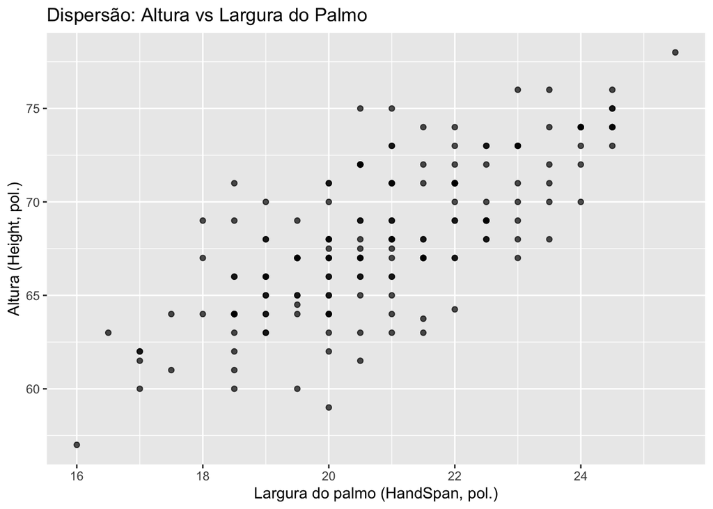

```r
# Dispersión Height vs HandSpan
ggplot(dados_hand, aes(x = HandSpan, y = Height)) +
  geom_point(alpha = 0.7) +
  labs(x = "Largura do palmo (HandSpan, pol.)", y = "Altura (Height, pol.)",
       title = "Dispersão: Altura vs Largura do Palmo")
```

**Interpretação do Gráfico** No nosso gráfico, o eixo X é a largura do palmo e o eixo Y é a altura da pessoa. Pode-se observar como se forma uma linha com tendência positiva, o que nos leva a crer que, quanto maior a largura do palmo, maior será a altura. A nuvem pode ser considerada razoavelmente homogênea, sem curvatura.

2. Ajuste o m de regressão linear simples utilizando a função `lm()` e apresente os resultados. **Dica**: use a função `summary()`.

```r
m <- lm(Height ~ HandSpan, data = dados_hand)
summary(m)
```

```
##
## Call:
## lm(formula = Height ~ HandSpan, data = dados_hand)
##
## Residuals:
##    Min     1Q Median     3Q    Max
## -7.727 -1.727 -0.167  1.493  7.493
##
## Coefficients:
##             Estimate Std. Error t value Pr(>|t|)
## (Intercept)   35.525      2.316    15.3   <2e-16 ***
## HandSpan       1.560      0.111    14.1   <2e-16 ***
## ---
## Signif. codes:  0 '***' 0.001 '**' 0.01 '*' 0.05 '.' 0.1 ' ' 1
##
## Residual standard error: 2.74 on 165 degrees of freedom
## Multiple R-squared:  0.547,  Adjusted R-squared:  0.544
## F-statistic:  199 on 1 and 165 DF,  p-value: <2e-16
```

3. Apresente a tabela ANOVA e identifique nesta tabela as somas de quadrados $SQReg$, $SQE$ e $SQT$. Qual a estimativa da variância $\sigma^2$? **Dica**: use a função `anova()`.

```r
anova(m)
```

```
## Analysis of Variance Table
##
## Response: Height
##            Df Sum Sq Mean Sq F value Pr(>F)
## HandSpan    1   1500    1500     199 <2e-16 ***
## Residuals 165   1243       8
## ---
## Signif. codes:  0 '***' 0.001 '**' 0.01 '*' 0.05 '.' 0.1 ' ' 1
```

```r
tabela_anova <- anova(m)

# A estimativa da variância σ² é o Mean Square Residual (Quadro Médio dos Resíduos)
estimativa_sigma2 <- tabela_anova["Residuals", "Mean Sq"]
# Verificando os cálculos
sqt <- sum((dados_hand$HandSpan - mean(dados_hand$HandSpan))^2)
sqreg <- sum((fitted(m) - mean(dados_hand$HandSpan))^2)
sqe <- sum(residuals(m)^2)
```

**Interpretação da Tabela**

$SQReg = 1500$

$SQE = 1243$

E como sabemos pela teoria, **$SQT$** é a soma dos valores de **$SQReg$** e **$SQE$**, ou seja **$SQReg$ + $SQE$ = $2743$**.

A estimativa da variância $\sigma^2$ é o quadrado médio do Erro (QME), isto é, a Soma de Quadrados do Erro dividida pelos seus graus de liberdade; neste caso, o número de estudantes menos 2, ou seja, $gl_E = 165$.

Portanto, a estimativa da variância $\sigma^2$ é $7{,}533$.

4. Apresente um gráfico de dispersão dos dados juntamente com a reta de regressão ajustada, usando a função `geom_smooth()`. Escreva um parágrafo com as interpretação dos parâmetros.

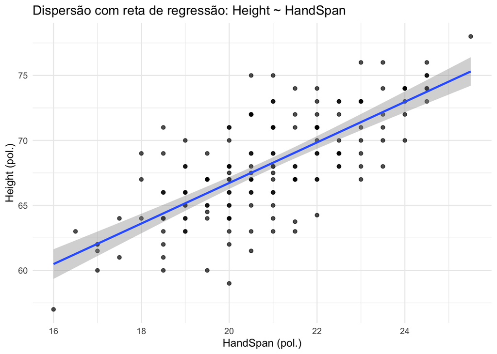

```r
ggplot(dados_hand, aes(x = HandSpan, y = Height)) +
  geom_point(alpha = 0.7) +
  geom_smooth(method = "lm", se = TRUE) +  # banda = IC(95%) para la media E[Y|X]
  labs(
    title = "Dispersão com reta de regressão: Height ~ HandSpan",
    x = "HandSpan (pol.)",
    y = "Height (pol.)"
  ) +
  theme_minimal()
```

**Interpretação da Tabela** O gráfico de dispersão mostra uma relação linear e positiva entre a largura do palmo e a altura. A reta ajustada representa a média $E(Y \mid X)$ do modelo $Y=\beta_0+\beta_1 X+\varepsilon$. Da saída do 2, vemos que a reta ajustada é $Y=35{,}525+1{,}560\,X$, cujo coeficiente angular é $\beta_1=1{,}560$ e o intercepto $\beta_0=35{,}525$; isto é a altura média estimada quando $X=0$ (sem sentido prático; a interpretação é apenas algébrica). A faixa sombreada é o IC(95%) para a resposta média $E(Y \mid X)$; é mais estreita perto da média de $X$ e se alarga ao se afastar, como prevê a variância de $\hat{Y}_h$.

5. Faça a análise de resíduos. Vamos começar pelos gráficos descritos no itens abaixo. O que você observa? Existe alguma tendência aparente nos gráficos?
   1. Resíduos versus a variável preditora.
   2. Resíduos versus valores peditos.

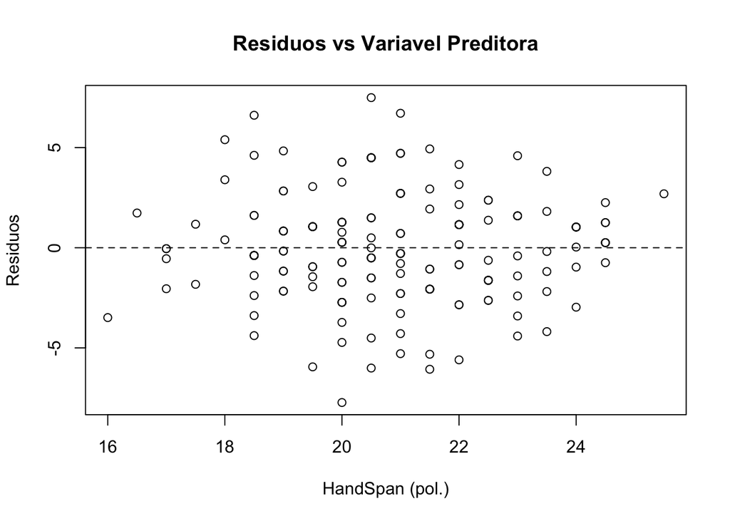

```r
m   <- lm(Height ~ HandSpan, data = dados_hand)
res <- residuals(m)
fit <- fitted(m)

# 5a) Residuos vs variable predictora
plot(dados_hand$HandSpan, res,
     xlab = "HandSpan (pol.)", ylab = "Residuos",
     main = "Residuos vs Variavel Preditora")
abline(h = 0, lty = 2)
```

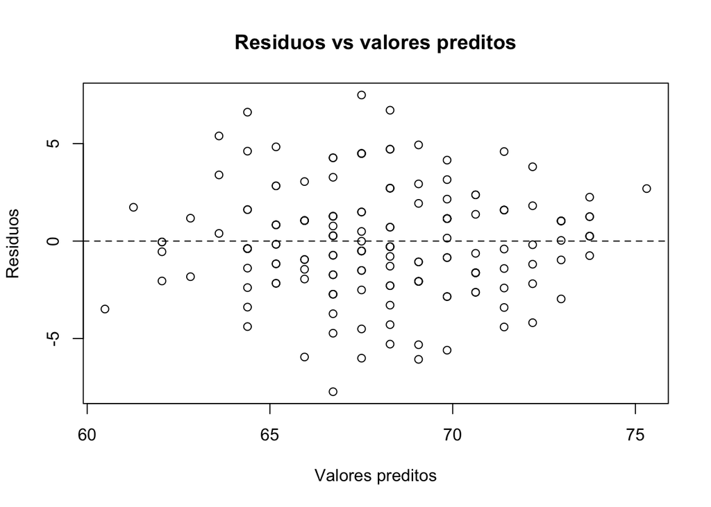

```r
# 5b) Residuos vs valores predichos
plot(fit, res,
     xlab = "Valores preditos", ylab = "Residuos",
     main = "Residuos vs valores preditos")
abline(h = 0, lty = 2)
```

*Interpretação Dos Gráficos*

A nuvem está centrada em torno de 0, não tem curvaturas nem inclinações, portanto não há tendência aparente. A dispersão é mais ou menos constante ao longo de , com alguns resíduos extremos (cerca de $\pm 7$). Em conjunto, o gráfico é consistente com a linearidade de $E(Y \mid X)$ e com homocedasticidade aproximada.

A nuvem também está centrada em torno de 0 e não apresenta curvaturas nem inclinações, de modo que não há evidência de não linearidade do m. Também não se observa formação de ``cone’’ que indique heterocedasticidade, confirmando o do primeiro inciso: a variabilidade é mais ou menos constante, o que é compatível com homocedasticidade. Em conclusão, o gráfico respalda que os pressupostos de linearidade e de variância aproximadamente constante são razoáveis.

6. Analise a suposição de normalidade dos resíduos das seguintes formas:
   1. Graficamente: boxplot, histograma e QQ-plot. Comente.
   2. Teste de hipótese. Escolha um teste apropriado, aplique e comente.

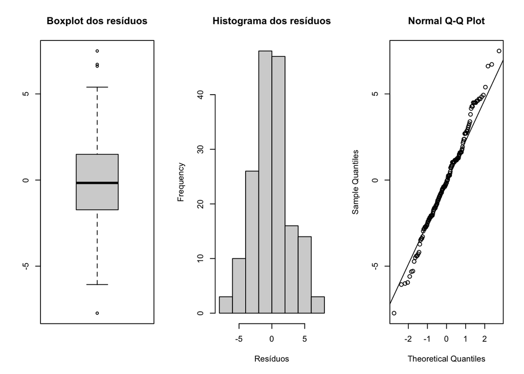

```r
res <- residuals(m)
par(mfrow=c(1,3))
boxplot(res, main="Boxplot dos resíduos")
hist(res, main="Histograma dos resíduos", xlab="Resíduos")
qqnorm(res); qqline(res)
```

```r
par(mfrow=c(1,1))
```

**Interpretação Dos Gráficos**

está centrado perto de 0 e é bastante simétrico; aparecem poucos pontos extremos nas caudas. Isso sugere que os resíduos não apresentam assimetrias marcantes.

pode-se ver que forma aproximadamente uma campana, centrada em 0, coerente com a distribuição normal dos resíduos.

pode-se ver como os pontos seguem bem a reta de regressão, com alguns desvios nas caudas, sem apresentar curvaturas.

2. Teste de hipótese. Escolha um teste apropriado, aplique e comente.

```r
# Asumiendo que ya ajustaste:
# m <- lm(Height ~ HandSpan, data = dados_hand)

# 1) Residuos crudos
res <- residuals(m)           # o: res <- resid(m)
shapiro.test(res)
```

```
##
##  Shapiro-Wilk normality test
##
## data:  res
## W = 1, p-value = 0.6
```

```r
# (opcional) Residuos estandarizados
rstd <- rstandard(m)
shapiro.test(rstd)
```

```
##
##  Shapiro-Wilk normality test
##
## data:  rstd
## W = 1, p-value = 0.6
```

```r
# (opcional) Mini-reporte automático
p <- shapiro.test(res)$p.value
cat(sprintf("Shapiro–Wilk p-valor = %.4f -> %s\n",
            p, ifelse(p < 0.05, "rechazo de normalidad", "no se rechaza normalidad")))
```

```
## Shapiro–Wilk p-valor = 0.5706 -> no se rechaza normalidad
```

Escolhemos o teste de Shapiro–Wilk; o que nos importa verificar é a hipótese de que os erros (e portanto os resíduos) seguem uma Normal. Seu estatístico baseia-se na correlação entre os resíduos ordenados e os quantis normais esperados; se a correlação é alta, há evidência de normalidade.

**Hipóteses**

$H_0$:os erros (e portanto os resíduos) seguem uma Normal,

$H_1$:não normalidade.

**Resultados do teste** Aplicado aos resíduos brutos e aos padronizados, obtenho $W \approx 0{,}993$ e $p \approx 0{,}571$ em ambos os casos.

Decisão ($\alpha=0{,}05$): não se rejeita $H_0$.

Conclusão.A evidência é consistente com normalidade dos resíduos, em coerência com o diagnóstico gráfico (boxplot, histograma e QQ-plot), onde os pontos seguem razoavelmente a reta.

7. Verifique através de um teste de hipótese a suposição de homocedasticidade.

```r
#Hipóteses do Teste:
#H₀: Homocedasticidade (variância constante dos resíduos)
#H₁: Heterocedasticidade (variância não constante dos resíduos)
# Teste de Breusch-Pagan para homocedasticidade

# Executar o teste
bp_test <- bptest(m)
cat("Teste de Breusch-Pagan para homocedasticidade:\n")
```

```
## Teste de Breusch-Pagan para homocedasticidade:
```

```r
print(bp_test)
```

```
##
##  studentized Breusch-Pagan test
##
## data:  m
## BP = 0.9, df = 1, p-value = 0.3
```

```r
# Nível de significância
alpha <- 0.05

# Interpretação
if (bp_test$p.value > alpha) {
  cat("CONCLUSÃO: Não rejeitamos hipotese nula. Não há evidências de heterocedasticidade (p =",
      round(bp_test$p.value, 4), ").\n")
  cat("A suposição de homocedasticidade é satisfeita.\n")
} else {
  cat("CONCLUSÃO: Rejeitamos a hipotese nula. Há evidências de heterocedasticidade (p =",
      round(bp_test$p.value, 4), ").\n")
  cat("A suposição de homocedasticidade NÃO é satisfeita.\n")
}
```

```
## CONCLUSÃO: Não rejeitamos hipotese nula. Não há evidências de heterocedasticidade (p = 0.339 ).
## A suposição de homocedasticidade é satisfeita.
```

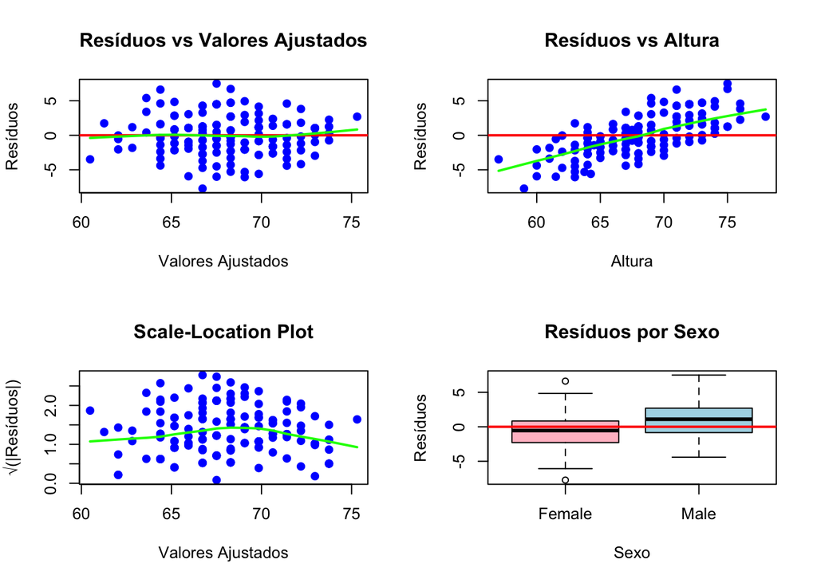

```r
# Gráficos para verificar homocedasticidade
par(mfrow = c(2, 2))
# 1. Resíduos vs Valores Ajustados
plot(fitted(m), residuals(m),
     main = "Resíduos vs Valores Ajustados",
     xlab = "Valores Ajustados", ylab = "Resíduos",
     pch = 19, col = "blue")
abline(h = 0, col = "red", lwd = 2)
lines(lowess(fitted(m), residuals(m)), col = "green", lwd = 2)

# 2. Resíduos vs Altura
plot(dados_hand$Height, residuals(m),
     main = "Resíduos vs Altura",
     xlab = "Altura", ylab = "Resíduos",
     pch = 19, col = "blue")
abline(h = 0, col = "red", lwd = 2)
lines(lowess(dados_hand$Height, residuals(m)), col = "green", lwd = 2)

# 3. Scale-Location Plot
sqrt_abs_resid <- sqrt(abs(residuals(m)))
plot(fitted(m), sqrt_abs_resid,
     main = "Scale-Location Plot",
     xlab = "Valores Ajustados", ylab = "√(|Resíduos|)",
     pch = 19, col = "blue")
lines(lowess(fitted(m), sqrt_abs_resid), col = "green", lwd = 2)

# 4. Resíduos por Sexo
boxplot(residuals(m) ~ dados_hand$Sex,
        main = "Resíduos por Sexo",
        xlab = "Sexo", ylab = "Resíduos",
        col = c("pink", "lightblue"))
abline(h = 0, col = "red", lwd = 2)
```

**Interpretação dos Resultados:** Os gráficos e testes estatísticos permitem avaliar se a variância dos resíduos é constante:

No gráfico “Resíduos vs Valores Ajustados”, os pontos devem estar aleatoriamente dispersos em torno de zero

A linha verde (lowess) deve ser aproximadamente horizontal

Valores de p > 0.05 no teste de Breusch-Pagan indicam homocedasticidade

**Conclusão**:

**Não rejeitamos $H_0$.** Não há evidências de heterocedasticidade **(p = 0.339 ).** A suposição de homocedasticidade é satisfeita.

8. É possível aplicar o teste F de falta de ajuste para esse dados? Se sim, apresente a tabela ANOVA com a decomposição da SQE em SQFA e SQEp. Indique quais hipóteses estão sendo testadas, a estatística do teste e conclusão.

```r
replic_count <- dados_hand %>% group_by(HandSpan) %>% summarise(n = n()) %>% arrange(desc(n))
head(replic_count, 10)
```

```
## # A tibble: 10 × 2
##    HandSpan     n
##       <dbl> <int>
##  1     20      20
##  2     21      18
##  3     20.5    17
##  4     22      15
##  5     18.5    13
##  6     19      12
##  7     21.5    11
##  8     19.5    10
##  9     22.5    10
## 10     23       9
```

```r
if (any(replic_count$n > 1)) {
  # Existem  replicações:  entao podemos comparar o modelo linear com um modelo que trata HandSpan como fator
  modelo_fac <- lm(Height ~ factor(HandSpan), data = dados_hand)
  # ANOVA comparando modelos (modelo linear vs modelo saturado por níveis de HandSpan)
  anova_compare <- anova(m, modelo_fac)
  print(anova_compare)
  # Explicação:
  # - H0: o modelo linear é adequado (não há falta de ajuste).
  # - H1: há falta de ajuste (modelo categórico explica significativamente mais).
  # - Se p-valor associado à diferença for pequeno, rejeitamos H0 => falta de ajuste.
} else {
  message("Não existem replicações de HandSpan => teste formal de falta de ajuste F NÃO é aplicável.")
}
```

```
## Analysis of Variance Table
##
## Model 1: Height ~ HandSpan
## Model 2: Height ~ factor(HandSpan)
##   Res.Df  RSS Df Sum of Sq    F Pr(>F)
## 1    165 1243
## 2    148 1146 17      96.2 0.73   0.77
```

**Hipóteses do Teste**

$H_1$: O modelo de regressão linear NÃO é adequado.Existe uma falta de ajuste (as médias por valor de palmo não estão bem representadas pela reta).

A tabela ANOVA compara o modelo linear simples com um modelo mais flexível, no qual HandSpan é tratado como fator (permitindo uma média para cada valor distinto). O p-valor obtido (0.77) é muito maior que 0.05, indicando que não há evidência de falta de ajuste. Isso significa que o modelo linear é adequado para explicar a relação entre HandSpan e Height, já que um modelo mais complexo não melhora significativamente o ajuste.

Portanto, não rejeitamos $H_0$ e concluímos que a reta linear é suficiente para descrever os dados.

9. Depois de verificar as suposições do m através da análise dos resíduos, faça agora um teste de hipótese para checar se a relação linear entre `HandSpan` e `Height` é significativa.

```r
#H0: beta1 = 0 (não há relação linear entre HandSpan e Height).
#H1: beta1 !=0 (existe relação linear significativa).
#alfa: 5%
anova(m)
```

```
## Analysis of Variance Table
##
## Response: Height
##            Df Sum Sq Mean Sq F value Pr(>F)
## HandSpan    1   1500    1500     199 <2e-16 ***
## Residuals 165   1243       8
## ---
## Signif. codes:  0 '***' 0.001 '**' 0.01 '*' 0.05 '.' 0.1 ' ' 1
```

```r
summary(m)
```

```
##
## Call:
## lm(formula = Height ~ HandSpan, data = dados_hand)
##
## Residuals:
##    Min     1Q Median     3Q    Max
## -7.727 -1.727 -0.167  1.493  7.493
##
## Coefficients:
##             Estimate Std. Error t value Pr(>|t|)
## (Intercept)   35.525      2.316    15.3   <2e-16 ***
## HandSpan       1.560      0.111    14.1   <2e-16 ***
## ---
## Signif. codes:  0 '***' 0.001 '**' 0.01 '*' 0.05 '.' 0.1 ' ' 1
##
## Residual standard error: 2.74 on 165 degrees of freedom
## Multiple R-squared:  0.547,  Adjusted R-squared:  0.544
## F-statistic:  199 on 1 and 165 DF,  p-value: <2e-16
```

```r
# olhar p-valor do coeficiente HandSpan e o F-statistic

# Interpretação:
# - H0: β1 = 0 (não há relação linear entre HandSpan e Height).
# - Se o p-valor do coeficiente HandSpan < 0.05 (ou nível escolhido), rejeitamos H0 e
#   concluímos que existe relação linear significativa.
```

Após o ajuste do modelo de regressão linear simples entre altura (Height) e largura do palmo , foi realizado um teste de hipótese para verificar se existe relação linear significativa entre as variáveis. O teste considera:

$H_0$: $\beta_1$ = 0 não há relação linear entre o palmo e a altura

$H_1$: $\beta_1$ != 0 Existe uma relação linear entre o palmo e a altura

Os resultados do **summary(m)** mostram que o coeficiente associado a HandSpan foi estimado em **1.560** com **erro padrão de 0.111** , resultando em um valor-t de 14.1 e **valor-p menor que 2e-16** . Como o valor-p é muito inferior ao nível de significância usual de 5%, **rejeita-se a hipótese nula** . Portanto, conclui-se que existe uma relação linear estatisticamente significativa entre a largura do palmo e a altura dos estudantes

Além disso, o coeficiente de determinação **$R^2$=0.547** indica que aproximadamente 54,7% da variação da altura pode ser explicada pela largura do palmo, o que evidencia a relevância do modelo.

10. Qual é a altura média de estudantes cuja largura do palmo é 17, 21 e 24 polegadas, respectivamente. Apresente também um intervalo de 95% de confiança para estes casos e compare-os. **Dica**: usar a função `predict()`.

```r
# Novos valores de HandSpan
novos <- data.frame(HandSpan = c(17, 21, 24))

# Previsão com intervalos de confiança (95%)
predict(m, novos, interval = "confidence", level = 0.95)
```

```
##    fit  lwr  upr
## 1 62.0 61.1 63.0
## 2 68.3 67.9 68.7
## 3 73.0 72.2 73.8
```

**Explicação dos resultados:**

O valor fit corresponde à estimativa da altura média esperada para um estudante com determinada largura do palmo.

Os valores lwr e upr representam os limites inferior e superior do intervalo de confiança de 95% para essa média estimada.

Esses intervalos de confiança refletem a incerteza associada à estimativa da média. Eles tendem a ser mais estreitos em torno da média dos valores observados de palmo, onde há maior concentração de dados, e mais largos em regiões afastadas, refletindo maior incerteza ao extrapolar para valores extremos de palmo

11. Para um novo estudante, qual a estimativa de sua altura dado que sua largura do palmo é 17, 21 e 24 polegadas, respectivamente. Apresente também um intervalo de predição de 95% para esses casos. Compare com os intervalos de confiança obtidos no item anterior. **Dica**: usar a função `predict()` modificando o arguemnto `interval`.

```r
predict <- predict(m, novos, interval = "prediction", level = 0.95)
predict
```

```
##    fit  lwr  upr
## 1 62.0 56.5 67.5
## 2 68.3 62.9 73.7
## 3 73.0 67.5 78.4
```

**Explicação:**

O intervalo de predição (prediction interval) fornece uma faixa onde esperamos que uma nova observação individual caia, dado o valor do palmo (HandSpan).

Ele é mais largo que o intervalo de confiança da média, porque leva em conta tanto a incerteza na estimativa dos coeficientes quanto a variabilidade individual (erro aleatório).

Comparando com o item anterior (intervalos de confiança para a média), os intervalos de predição são sempre maiores, refletindo a maior incerteza ao prever um indivíduo específico em vez da média.

12. Apresente um gráfico de dispersão, juntamente com a reta ajustada e a banda de confiança para estimação da resposta média e o intervalo de predição para uma nova observação, ambos com nível de confiança de 95%.

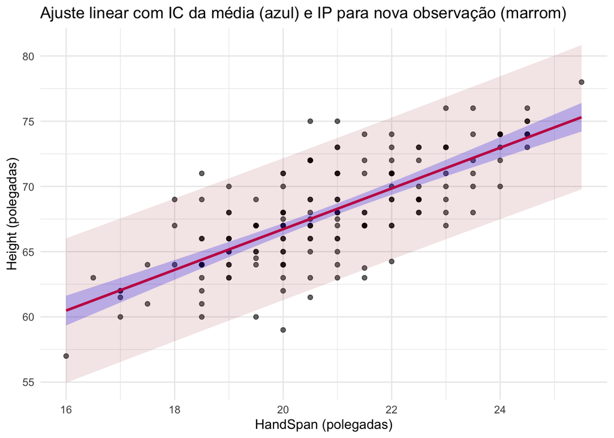

```r
dados <- readr::read_table("handheight.txt")

grid <- data.frame(HandSpan = seq(min(dados$HandSpan),
                                  max(dados$HandSpan),
                                  length.out = 200))

pred_conf <- predict(m, newdata = grid, interval = "confidence", level = 0.95)
pred_pred <- predict(m, newdata = grid, interval = "prediction", level = 0.95)

# Juntar resultados no grid
grid <- cbind(grid, pred_conf)
colnames(grid)[2:4] <- c("fit", "lwr_conf", "upr_conf")
grid$lwr_pred <- pred_pred[, "lwr"]
grid$upr_pred <- pred_pred[, "upr"]

# Plot
ggplot() +
  geom_point(data = dados, aes(x = HandSpan, y = Height), color = "black", alpha = 0.6) +
  geom_line(data = grid, aes(x = HandSpan, y = fit), color = "red", size = 1) +
  geom_ribbon(data = grid, aes(x = HandSpan, ymin = lwr_conf, ymax = upr_conf),
              alpha = 0.25, fill = "blue") +   # banda de confiança para a média
  geom_ribbon(data = grid, aes(x = HandSpan, ymin = lwr_pred, ymax = upr_pred),
              alpha = 0.12, fill = "brown") + # banda de predição para nova obs
  labs(title = "Ajuste linear com IC da média (azul) e IP para nova observação (marrom)",
       x = "HandSpan (polegadas)",
       y = "Height (polegadas)") +
  theme_minimal()
```

**Descrição do gráfico:**

Os pontos pretos representam os dados observados de altura em função da largura do palmo (HandSpan).

A linha vermelha corresponde à reta ajustada pelo modelo linear, ou seja, a estimativa pontual da altura para cada valor de HandSpan.

A faixa azul indica o intervalo de confiança de 95% para a média da altura, mostrando onde esperamos que a média da população esteja para cada valor de HandSpan.

A faixa marrom representa o intervalo de predição de 95% para uma nova observação individual, ou seja, a faixa onde é mais provável que caia a altura de um novo estudante com o HandSpan correspondente.

**Observações importantes:**

O intervalo de predição é sempre mais largo que o intervalo de confiança, pois incorpora não apenas a incerteza do modelo, mas também a variabilidade individual dos dados.

Ambas as faixas (IC e IP) são mais estreitas próximas à média dos valores de HandSpan e tendem a se alargar nas extremidades, refletindo maior incerteza na predição para valores fora do centro da amostra.

Este gráfico permite visualizar simultaneamente a relação linear entre HandSpan e Height, a incerteza na estimativa da média e a variabilidade esperada em novos indivíduos.